# `Problem statement (Term Deposit Sale)`

## `Goal`

Using the data collected from existing customers, build a model that will help the marketing team identify potential customers who are relatively more likely to subscribe term deposit and thus increase their hit ratio.

## `Resources Available`

The historical data for this project is available in file https://archive.ics.uci.edu/ml/datasets/Bank+Marketing

## `Deliverable – 1 (Exploratory data quality report reflecting the following) – (20)`

### `1. Univariate analysis (12 marks)`

`1. Univariate analysis`

a. data types and description of the independent attributes which should include (name, meaning, range of values observed, central values (mean and median), standard deviation and quartiles, analysis of the body of distributions / tails, missing values, outliers.

b. Strategies to address the different data challenges such as data pollution, outlier’s treatment and missing values treatment.

c. Please provide comments in jupyter notebook regarding the steps you take and insights drawn from the plots.

### `2. Multivariate analysis (8 marks)`

a. Bi-variate analysis between the predictor variables and target column. Comment on your findings in terms of their relationship and degree of relation if any. Visualize the analysis using boxplots and pair plots, histograms or density curves. Select the most appropriate attributes.

b. Please provide comments in jupyter notebook regarding the steps you take and insights drawn from the plots

## `Deliverable – 2 (Prepare the data for analytics) – (10)`

1. Ensure the attribute types are correct. If not, take appropriate actions.
2. Get the data model ready.
3. Transform the data i.e. scale / normalize if required
4. Create the training set and test set in ratio of 70:30

## `Deliverable – 3 (create the ensemble model) – (30)`

1. First create models using Logistic Regression and Decision Tree algorithm. Note the model performance by using different matrices. Use confusion matrix to evaluate class level metrics i.e. Precision/Recall. Also reflect the accuracy and F1 score of the model. (10 marks)
2. Build the ensemble models (Bagging and Boosting) and note the model performance by using different matrices. Use same metrics as in above model. (at least 3 algorithms) (15 marks)
3. Make a DataFrame to compare models and their metrics. Give conclusion regarding the best algorithm and your reason behind it. (5 marks)

## `Attribute information`

### `Input variables:`

#### `Bank client data:`

1. `age:` Continuous feature
2. `job:` Type of job (management, technician, entrepreneur, blue-collar, etc.)
3. `marital:` marital status (married, single, divorced)
4. `education:` education level (primary, secondary, tertiary)
5. `default:` has credit in default?
6. `housing:` has housing loan?
7. `loan:` has personal loan?
8. `balance` in account

Related to previous contact:

1. `contact:` contact communication type
2. `month:` last contact month of year
3. `day:` last contact day of the month
4. `duration:` last contact duration, in seconds*

#### `Other attributes:`

1. `campaign:` number of contacts performed during this campaign and for this client
2. `pdays:` number of days that passed by after the client was last contacted from a previous campaign (-1 tells us the person has not been contacted or contact period is beyond 900 days)
3. `previous:` number of times the client has been contacted before for the last campaign to subscribe term deposit
4. `poutcome:` outcome of the previous marketing campaign

### `Output variable (desired target):`

1. `Target:` Tell us has the client subscribed a term deposit. (Yes, No)

## `Deliverable – 1 (Exploratory data quality report reflecting the following) – (20)`

#### `Import all the header libraries`

```python
import os, sys, re
import numpy as np
import pandas as pd
pd.options.display.float_format = '{:,.4f}'.format

# For Plot
import matplotlib.pyplot as plt
import seaborn as sns
# Add nice background to the graphs
sns.set(color_codes=True)
# To enable plotting graphs in Jupyter notebook
%matplotlib inline

import pydotplus
import graphviz

# sklearn libraries
from sklearn.preprocessing import RobustScaler
from sklearn.model_selection import train_test_split
from sklearn.linear_model import LogisticRegression
from sklearn.tree import export_graphviz
from sklearn.tree import DecisionTreeClassifier
from sklearn.ensemble import RandomForestClassifier
from sklearn.ensemble import AdaBoostClassifier
from sklearn.ensemble import BaggingClassifier
from sklearn.ensemble import GradientBoostingClassifier

# calculate confusion matrix and various performance metrics
from sklearn.metrics import confusion_matrix, recall_score, \
    precision_score, f1_score, accuracy_score
#AUC ROC curve
from sklearn.metrics import roc_auc_score, roc_curve

# Additional libs
from yellowbrick.classifier import ClassificationReport, ROCAUC
from six import StringIO

from IPython.display import Image
from IPython.core.display import display, HTML
display(HTML("<style>.container { width:95% !important; }</style>"))
```

#### `Read the input file into pandas dataframe`

```python
bank_df = pd.read_csv('bank-full.csv')
bank_df.head(10)
```

|  | age | job | marital | education | default | balance | housing | loan | contact | day | month | duration | campaign | pdays | previous | poutcome | Target |
| --- | --- | --- | --- | --- | --- | --- | --- | --- | --- | --- | --- | --- | --- | --- | --- | --- | --- |
| 0 | 58 | management | married | tertiary | no | 2143 | yes | no | unknown | 5 | may | 261 | 1 | -1 | 0 | unknown | no |
| 1 | 44 | technician | single | secondary | no | 29 | yes | no | unknown | 5 | may | 151 | 1 | -1 | 0 | unknown | no |
| 2 | 33 | entrepreneur | married | secondary | no | 2 | yes | yes | unknown | 5 | may | 76 | 1 | -1 | 0 | unknown | no |
| 3 | 47 | blue-collar | married | unknown | no | 1506 | yes | no | unknown | 5 | may | 92 | 1 | -1 | 0 | unknown | no |
| 4 | 33 | unknown | single | unknown | no | 1 | no | no | unknown | 5 | may | 198 | 1 | -1 | 0 | unknown | no |
| 5 | 35 | management | married | tertiary | no | 231 | yes | no | unknown | 5 | may | 139 | 1 | -1 | 0 | unknown | no |
| 6 | 28 | management | single | tertiary | no | 447 | yes | yes | unknown | 5 | may | 217 | 1 | -1 | 0 | unknown | no |
| 7 | 42 | entrepreneur | divorced | tertiary | yes | 2 | yes | no | unknown | 5 | may | 380 | 1 | -1 | 0 | unknown | no |
| 8 | 58 | retired | married | primary | no | 121 | yes | no | unknown | 5 | may | 50 | 1 | -1 | 0 | unknown | no |
| 9 | 43 | technician | single | secondary | no | 593 | yes | no | unknown | 5 | may | 55 | 1 | -1 | 0 | unknown | no |

### `1. Univariate analysis (12 marks)`

`1. Univariate analysis`

a. Data types and description of the independent attributes which should include (name, meaning, range of values observed, central values (mean and median), standard deviation and quartiles, analysis of the body of distributions / tails, missing values, outliers).

b. Strategies to address the different data challenges such as data pollution, outlier’s treatment and missing values treatment.

c. Please provide comments in jupyter notebook regarding the steps you take and insights drawn from the plots.

#### Print the shape and the datatypes of each column

```python
# Shape of the dataframe
bank_df.shape
```

```
(45211, 17)
```

```python
# Datatypes of each columns
bank_df.dtypes
```

```
age           int64
job          object
marital      object
education    object
default      object
balance       int64
housing      object
loan         object
contact      object
day           int64
month        object
duration      int64
campaign      int64
pdays         int64
previous      int64
poutcome     object
Target       object
dtype: object
```

**Insights:**

`There are 17 columns and 45211 rows in the dataset. Looking at the output of the dtypes, observed that there are many object columns and I will treat/convert/drop them as needed in data preperation step`

#### Print the descriptive statistics (min, max, mean, median, standard deviation and quartiles) of each & every column using describe() function and missing values using info() and isnull() functions

```python
# Analyse the statistical summary and the distribution of the various attributes
bank_df.describe().transpose()
```

|  | count | mean | std | min | 25% | 50% | 75% | max |
| --- | --- | --- | --- | --- | --- | --- | --- | --- |
| age | 45,211.0000 | 40.9362 | 10.6188 | 18.0000 | 33.0000 | 39.0000 | 48.0000 | 95.0000 |
| balance | 45,211.0000 | 1,362.2721 | 3,044.7658 | -8,019.0000 | 72.0000 | 448.0000 | 1,428.0000 | 102,127.0000 |
| day | 45,211.0000 | 15.8064 | 8.3225 | 1.0000 | 8.0000 | 16.0000 | 21.0000 | 31.0000 |
| duration | 45,211.0000 | 258.1631 | 257.5278 | 0.0000 | 103.0000 | 180.0000 | 319.0000 | 4,918.0000 |
| campaign | 45,211.0000 | 2.7638 | 3.0980 | 1.0000 | 1.0000 | 2.0000 | 3.0000 | 63.0000 |
| pdays | 45,211.0000 | 40.1978 | 100.1287 | -1.0000 | -1.0000 | -1.0000 | -1.0000 | 871.0000 |
| previous | 45,211.0000 | 0.5803 | 2.3034 | 0.0000 | 0.0000 | 0.0000 | 0.0000 | 275.0000 |

```python
# many columns are of type object i.e. strings. These columns need to be converted to ordinal type
bank_df.info()
```

```
<class 'pandas.core.frame.DataFrame'>
RangeIndex: 45211 entries, 0 to 45210
Data columns (total 17 columns):
 #   Column     Non-Null Count  Dtype
---  ------     --------------  -----
 0   age        45211 non-null  int64
 1   job        45211 non-null  object
 2   marital    45211 non-null  object
 3   education  45211 non-null  object
 4   default    45211 non-null  object
 5   balance    45211 non-null  int64
 6   housing    45211 non-null  object
 7   loan       45211 non-null  object
 8   contact    45211 non-null  object
 9   day        45211 non-null  int64
 10  month      45211 non-null  object
 11  duration   45211 non-null  int64
 12  campaign   45211 non-null  int64
 13  pdays      45211 non-null  int64
 14  previous   45211 non-null  int64
 15  poutcome   45211 non-null  object
 16  Target     45211 non-null  object
dtypes: int64(7), object(10)
memory usage: 5.9+ MB
```

```python
# Cross validate the Non-Null value reported by info()
bank_df.isnull().sum()
```

```
age          0
job          0
marital      0
education    0
default      0
balance      0
housing      0
loan         0
contact      0
day          0
month        0
duration     0
campaign     0
pdays        0
previous     0
poutcome     0
Target       0
dtype: int64
```

**Insights:**

`Looking at the output of the describe(), I observed that I didn't get information about the columns which has datatype=object. Describe ONLY works with int/float/double variables. The output of info(), and isnull() says that there are no colums with missing values. I will revisit this section when I convert object variables to categorical or numrical values in the data preparation stage. I will also work on treating -ve values in data preparation section if required`

#### Let's use univariate analysis and check the some of the individual attributes for their basic statistic such as central values, spread, tails etc.

```python
# Check the unique values in each column of the dataframe.
bank_df.nunique()
```

```
age            77
job            12
marital         3
education       4
default         2
balance      7168
housing         2
loan            2
contact         3
day            31
month          12
duration     1573
campaign       48
pdays         559
previous       41
poutcome        4
Target          2
dtype: int64
```

```python
# List all the columns of the dataframe
bank_df.columns
```

```
Index(['age', 'job', 'marital', 'education', 'default', 'balance', 'housing',
       'loan', 'contact', 'day', 'month', 'duration', 'campaign', 'pdays',
       'previous', 'poutcome', 'Target'],
      dtype='object')
```

```python
# Let's visualize the individual data with datatype=(int/float/double) and see how do they look. This helps in further decision making about the data
bank_df[bank_df.columns].hist(stacked=False, bins=100, figsize=(30,30), layout=(10,2));
```

[figure not shown]

**Insights:**

```
Followings are the observatios from the above hist plot and the discribe() outputs:
1). There are mamy samples for the young customers which shows many young customers prefer account with bank. The graph shows spread towards age 30 and 40 and some in 50's so mean age is 40
2). There are many customer with balanace towards 1500 and also observed the extreme side
3). Campaign shows the most customer are contacted < 3 times
4). Days don't give more information as distibution looks mostly uniform
5). The most customer are contacted for smaller durations in seconds
```

##### Let's plot some of the object variables like Job, marital status and education

```python
# Let's plot count plot for jobs
sns.countplot(bank_df['job'])
plt.xticks(
    rotation=90,
    horizontalalignment='center',
    fontweight='normal',
    fontsize='large'
)
plt.show()
```

[figure not shown]

```python
# Let's plot count plot for marital status
sns.countplot(bank_df['marital'])
plt.xticks(
    rotation=90,
    horizontalalignment='center',
    fontweight='normal',
    fontsize='large'
)
plt.show()
```

[figure not shown]

```python
# Let's do count plot for education
sns.countplot(bank_df['education'])
plt.xticks(
    rotation=90,
    horizontalalignment='center',
    fontweight='normal',
    fontsize='large'
)
plt.show()
```

[figure not shown]

```python
# Check the details for the months
sns.countplot(bank_df['month'])
plt.xticks(
    rotation=90,
    horizontalalignment='center',
    fontweight='normal',
    fontsize='large'
)
plt.show()
```

[figure not shown]

**Insights:**

```
Looking at the above count plots, following observatios can be made:
1). There are more existing customers from management, technician and blue-collar jobs.
2). There are more existing customers who are married and very few who are divorced.
3). There are more existing customers who has secondary education followed by tertiary education.
4). There are more customer who have been contacted during the months of may, june, july and Aug have deposit accounts
```

NOTE: You can't draw distplot with columns with string variables

```python
# Let's implement the valueCount function
def valueCount(pd_df=None):
    columns = pd_df.columns
    for col in columns:
        print('value_counts for {}'.format(col))
        print(pd_df[col].value_counts(normalize=True).head(10))
        print()
```

```python
# Let's print the value count value of all the variables. Let's limit the rows to 10 for better visibility
valueCount(bank_df)
```

```
value_counts for age
32   0.0461
31   0.0441
33   0.0436
34   0.0427
35   0.0419
36   0.0399
30   0.0389
37   0.0375
39   0.0329
38   0.0324
Name: age, dtype: float64

value_counts for job
blue-collar     0.2153
management      0.2092
technician      0.1680
admin.          0.1144
services        0.0919
retired         0.0501
self-employed   0.0349
entrepreneur    0.0329
unemployed      0.0288
housemaid       0.0274
Name: job, dtype: float64

value_counts for marital
married    0.6019
single     0.2829
divorced   0.1152
Name: marital, dtype: float64

value_counts for education
secondary   0.5132
tertiary    0.2942
primary     0.1515
unknown     0.0411
Name: education, dtype: float64

value_counts for default
```

[output cut: 107 more lines]

```
8   0.0029
9   0.0020
Name: previous, dtype: float64

value_counts for poutcome
unknown   0.8175
failure   0.1084
other     0.0407
success   0.0334
Name: poutcome, dtype: float64

value_counts for Target
no    0.8830
yes   0.1170
Name: Target, dtype: float64
```

**Insights:**

```
Looking at the value_count() dump and excluding previous observations, following observatios are made:
1). There are very few customers who have defaulted
2). There are more customers who owns house
3). There are more customers who don't have a personal loan
4). Most customers are contacted on cell phone during the previous campaign
5). The sucess outcome from the previous campaign is very less
6). There are only 12% customers who subscribed term deposits
```

### `2. Multivariate analysis (8 marks)`

a. Bi-variate analysis between the predictor variables and target column. Comment on your findings in terms of their relationship and degree of relation if any. Visualize the analysis using boxplots and pair plots, histograms or density curves. Select the most appropriate attributes.

b. Please provide comments in jupyter notebook regarding the steps you take and insights drawn from the plots

```python
# NOTE: Disabling the pair plot as It takes lots of memory and compute power.
# Let's plot pair plots to see the relation between variables
# plt.figure(figsize=(20,5))
# sns.pairplot(bank_df, hue='Target')
# plt.show()
```

```python
# Let's plot the box plot between Target and age. Analyse data for hue=job
# Set the plot window size
plt.figure(figsize=(20,5))
sns.boxplot(bank_df['Target'], bank_df['age'], hue=bank_df['job']);
plt.show()
```

[figure not shown]

```python
# Let's see the customer's various account relationship for Target, age, loan and defaults
bank_df.groupby(['age', 'job'])['Target'].value_counts()
```

```
age  job      Target
18   student  yes        7
              no         5
19   student  no        24
              yes       11
20   admin.   no         2
                        ..
92   retired  yes        2
93   retired  yes        2
94   retired  no         1
95   retired  no         1
              yes        1
Name: Target, Length: 1058, dtype: int64
```

```python
pd.crosstab(bank_df['age'],bank_df['Target'],normalize='index')
```

| Target age | no | yes |
| --- | --- | --- |
| 18 | 0.4167 | 0.5833 |
| 19 | 0.6857 | 0.3143 |
| 20 | 0.7000 | 0.3000 |
| 21 | 0.7215 | 0.2785 |
| 22 | 0.6899 | 0.3101 |
| ... | ... | ... |
| 90 | 0.0000 | 1.0000 |
| 92 | 0.0000 | 1.0000 |
| 93 | 0.0000 | 1.0000 |
| 94 | 1.0000 | 0.0000 |
| 95 | 0.5000 | 0.5000 |

77 rows × 2 columns

**Insights:**

[output not shown]

```python
# Let's plot relation between Target, age and defaults
plt.figure(figsize=(20,5))
sns.boxplot(bank_df['Target'], bank_df['age'], hue=bank_df['default']);
plt.show()
```

[figure not shown]

**Insights:**

`Observed that there are more customers with no defaults have more deposit account compare to the defaulted ones. It is very difficult to derive any conclusion for the people with no term deposit accounts`

```python
# Let's plot multiple categorical variables and analyse them such as Target, age, loan and defaults
sns.catplot(x="Target",
               y="age",
               hue="loan",
               col="default",
               data=bank_df,
               kind="bar");
plt.show()
```

[figure not shown]

**Insights:**

`There are fewer customers with age < 35 years who have term deposit and have personal loan accounts and have defaulted. Customers with age >40 have comparitively no loan accounts and defaults have deposit accounts`

```python
# Let's plot multiple categorical variables and analyse them such as Target, age, marital status and houseing
sns.catplot(x="Target",
               y="age",
               hue="marital",
               col="housing",
               data=bank_df,
               kind="bar");
plt.show()
```

[figure not shown]

**Insights:**

```
Following observations are made:
1). There are more customers who are divorced who don't have housing and have term deposit accounts and their age is > 50s.
2). There are more customer who are married and don't have housing and have term deposit accounts and their age is < 50.
```

```python
# Let's plot multiple categorical variables and analyse them
sns.catplot(x="Target",
               y="age",
               hue="education",
               col="housing",
               data=bank_df,
               kind="box");
plt.show()
```

[figure not shown]

**Insights:**

```
Following observations are made:
1). There are more customers who have primary education and don't have housing have term deposit accounts and their age is > 50 and < 75 with few outliers.
2). There are more customer who have secondary education and don't have housing and have term deposit accounts and their age is < 55 and > 30.
```

```python
# Let's plot multiple categorical variables and analyse them
sns.catplot(x="Target",
               y="campaign",
               hue="previous",
               col="poutcome",
               data=bank_df,
               kind="bar");
plt.show()
```

[figure not shown]

**Insights:**

`Observed that there are very few chance of sucess with campaign then failure`

```python
# Let's plot multiple categorical variables and analyse them
sns.catplot(x="Target",
               y="age",
               hue="job",
               col="poutcome",
               data=bank_df,
               kind="box");
plt.show()
```

[figure not shown]

**Insights:**

`Observed that there are more customer with outcome=sucess who are retired and have term deposite account and have age > 60s. For other jobs, it is difficult to make conclusion`

## `Deliverable – 2 (Prepare the data for analytics) – (10)`

1. Ensure the attribute types are correct. If not, take appropriate actions.
2. Get the data model ready.
3. Transform the data i.e. scale / normalize if required
4. Create the training set and test set in ratio of 70:30

#### Lets convert the columns with an 'object' datatype into categorical variables

```python
# Let's loop through all the columns and convert the columns with dtype=object to categorical variables
for col in bank_df.columns:
    if bank_df[col].dtype == 'object':
        bank_df[col] = pd.Categorical(bank_df[col])
bank_df.head()
```

|  | age | job | marital | education | default | balance | housing | loan | contact | day | month | duration | campaign | pdays | previous | poutcome | Target |
| --- | --- | --- | --- | --- | --- | --- | --- | --- | --- | --- | --- | --- | --- | --- | --- | --- | --- |
| 0 | 58 | management | married | tertiary | no | 2143 | yes | no | unknown | 5 | may | 261 | 1 | -1 | 0 | unknown | no |
| 1 | 44 | technician | single | secondary | no | 29 | yes | no | unknown | 5 | may | 151 | 1 | -1 | 0 | unknown | no |
| 2 | 33 | entrepreneur | married | secondary | no | 2 | yes | yes | unknown | 5 | may | 76 | 1 | -1 | 0 | unknown | no |
| 3 | 47 | blue-collar | married | unknown | no | 1506 | yes | no | unknown | 5 | may | 92 | 1 | -1 | 0 | unknown | no |
| 4 | 33 | unknown | single | unknown | no | 1 | no | no | unknown | 5 | may | 198 | 1 | -1 | 0 | unknown | no |

```python
# Check the dtypes again
bank_df.info()
```

```
<class 'pandas.core.frame.DataFrame'>
RangeIndex: 45211 entries, 0 to 45210
Data columns (total 17 columns):
 #   Column     Non-Null Count  Dtype
---  ------     --------------  -----
 0   age        45211 non-null  int64
 1   job        45211 non-null  category
 2   marital    45211 non-null  category
 3   education  45211 non-null  category
 4   default    45211 non-null  category
 5   balance    45211 non-null  int64
 6   housing    45211 non-null  category
 7   loan       45211 non-null  category
 8   contact    45211 non-null  category
 9   day        45211 non-null  int64
 10  month      45211 non-null  category
 11  duration   45211 non-null  int64
 12  campaign   45211 non-null  int64
 13  pdays      45211 non-null  int64
 14  previous   45211 non-null  int64
 15  poutcome   45211 non-null  category
 16  Target     45211 non-null  category
dtypes: category(10), int64(7)
memory usage: 2.8 MB
```

#### Let's separate the dependent and independent variables into X and Y variables. Also convert categorical features to dummy featuers

```python
bank_df_Y = bank_df[['Target']]
bank_df_X = bank_df.drop('Target', axis=1)
```

#### `NOTE:` Observed that there are possible columns like day, duration and month can be dropped but let's build model with all the data and if required, we can drop and recreate model later.

```python
# Convert categorical vriables to dummy variables
bank_df_X = pd.get_dummies(bank_df_X, drop_first=True)
print(bank_df_X.head())
```

```
   age  balance  day  duration  campaign  pdays  previous  job_blue-collar  \
0   58     2143    5       261         1     -1         0                0
1   44       29    5       151         1     -1         0                0
2   33        2    5        76         1     -1         0                0
3   47     1506    5        92         1     -1         0                1
4   33        1    5       198         1     -1         0                0

   job_entrepreneur  job_housemaid  ...  month_jul  month_jun  month_mar  \
0                 0              0  ...          0          0          0
1                 0              0  ...          0          0          0
2                 1              0  ...          0          0          0
3                 0              0  ...          0          0          0
4                 0              0  ...          0          0          0

   month_may  month_nov  month_oct  month_sep  poutcome_other  \
0          1          0          0          0               0
1          1          0          0          0               0
2          1          0          0          0               0
3          1          0          0          0               0
4          1          0          0          0               0

   poutcome_success  poutcome_unknown
0                 0                 1
1                 0                 1
2                 0                 1
3                 0                 1
4                 0                 1

[5 rows x 42 columns]
```

```python
# NOTE: We haven't treated Target variable previously and it was a columns of the string
# Let's replace no=0, yes=1
bank_df_Y = bank_df_Y.replace({"Target":{"no": 0, "yes": 1 }})
print(bank_df_Y)
```

```
       Target
0           0
1           0
2           0
3           0
4           0
...       ...
45206       1
45207       1
45208       1
45209       0
45210       0

[45211 rows x 1 columns]
```

```python
bank_df_X.info()
```

```
<class 'pandas.core.frame.DataFrame'>
RangeIndex: 45211 entries, 0 to 45210
Data columns (total 42 columns):
 #   Column               Non-Null Count  Dtype
---  ------               --------------  -----
 0   age                  45211 non-null  int64
 1   balance              45211 non-null  int64
 2   day                  45211 non-null  int64
 3   duration             45211 non-null  int64
 4   campaign             45211 non-null  int64
 5   pdays                45211 non-null  int64
 6   previous             45211 non-null  int64
 7   job_blue-collar      45211 non-null  uint8
 8   job_entrepreneur     45211 non-null  uint8
 9   job_housemaid        45211 non-null  uint8
```

[output cut: 34 more lines]

#### From looking at the box and cat plots, Observed many outliers in the data so let's normalize data to common scale to reduce the error. As we see many outlier, the min_max and z_score scaling methods won't be efficient mathods as they will have more bias due to large outliers. Let's use Robust scaling as it uses IQR and median and handles outliers better than other methods.

```python
# Create a robust scaler object
rbst_scaler = RobustScaler()
# Fit and transform the data
bank_df_X_rbst = pd.DataFrame(rbst_scaler.fit_transform(bank_df_X), columns=bank_df_X.columns)
print(bank_df_X_rbst)
```

```
          age  balance     day  duration  campaign    pdays  previous  \
0      1.2667   1.2500 -0.8462    0.3750   -0.5000   0.0000    0.0000
1      0.3333  -0.3090 -0.8462   -0.1343   -0.5000   0.0000    0.0000
2     -0.4000  -0.3289 -0.8462   -0.4815   -0.5000   0.0000    0.0000
3      0.5333   0.7802 -0.8462   -0.4074   -0.5000   0.0000    0.0000
4     -0.4000  -0.3296 -0.8462    0.0833   -0.5000   0.0000    0.0000
...       ...      ...     ...       ...       ...      ...       ...
45206  0.8000   0.2780  0.0769    3.6898    0.5000   0.0000    0.0000
45207  2.1333   0.9447  0.0769    1.2778    0.0000   0.0000    0.0000
45208  2.2000   3.8842  0.0769    4.3843    1.5000 185.0000    3.0000
45209  1.2000   0.1622  0.0769    1.5185    1.0000   0.0000    0.0000
45210 -0.1333   1.8606  0.0769    0.8380    0.0000 189.0000   11.0000

       job_blue-collar  job_entrepreneur  job_housemaid  ...  month_jul  \
0               0.0000            0.0000         0.0000  ...     0.0000
```

[output cut: 38 more lines]

#### Split the data into training and test set in the ratio of 70:30

```python
# Let's split the data into training and test set in the ratio of 70:30 respectively
X_train, X_test, y_train, y_test = train_test_split(bank_df_X_rbst, bank_df_Y, test_size=0.30, random_state=11)
```

```python
# print(X_train.head())
# print()
# print(y_train.head())
```

```python
# print(X_test.head())
# print()
# print(y_test.head())
```

## `Deliverable – 3 (create the ensemble model) – (30)`

1. First create models using Logistic Regression and Decision Tree algorithm. Note the model performance by using different matrices. Use confusion matrix to evaluate class level metrics i.e. Precision/Recall. Also reflect the accuracy and F1 score of the model. (10 marks)
2. Build the ensemble models (Bagging and Boosting) and note the model performance by using different matrices. Use same metrics as in above model. (at least 3 algorithms) (15 marks)
3. Make a DataFrame to compare models and their metrics. Give conclusion regarding the best algorithm and your reason behind it. (5 marks)

### Let's implement the common functions used for the all the models

```python
# Let's create an empty dictionary to store model name and performance matrix
m_perf_matrix = dict()
```

```python
## Create a function to get confusion matrix in a proper format
def pltConfusionMatrix(actual, predicted):
    cm = confusion_matrix(actual, predicted)
    sns.heatmap(cm, annot=True,  fmt='.4f', xticklabels=[0,1], yticklabels=[0,1])
    plt.ylabel('Observed')
    plt.xlabel('Predicted')
    plt.show()
```

```python
# Compute performance matrix
def computePerfMatrix(m_classifier, m_predict,):
    # Let's store all the perf variables in the dict.
    perf_matrix = dict()

    perf_matrix['training_accuracy'] = m_classifier.score(X_train,y_train)
    print("Trainig dataset accuracy:", m_classifier.score(X_train,y_train))
    print()
    perf_matrix['test_accuracy'] = m_classifier.score(X_test, y_test)
    print("Testing dataset accuracy:", m_classifier.score(X_test, y_test))
    print()
    print('Confusion Matrix:')
    print(pltConfusionMatrix(y_test,m_predict))
    print()
    perf_matrix['recall_score'] = recall_score(y_test,m_predict)
    print("Recall:",recall_score(y_test,m_predict))
    print()
    perf_matrix['precision_score'] = precision_score(y_test,m_predict)
    print("Precision:", precision_score(y_test,m_predict))
    print()
    perf_matrix['f1_score'] = f1_score(y_test,m_predict)
    print("F1 Score:",f1_score(y_test,m_predict))
    print()
    perf_matrix['roc_auc_score'] = roc_auc_score(y_test,m_predict)
    print("Roc Auc Score:",roc_auc_score(y_test,m_predict))
    print()
    # Return the model specific results
    return perf_matrix
```

```python
# Visualize the performance matrix
# # Visualize model's performance with yellowbrick library
def visualizePerfMatrix(m_classifier):
    viz = ClassificationReport(m_classifier)
    viz.fit(X_train, y_train)
    viz.score(X_test, y_test)
    viz.show()

    roc = ROCAUC(m_classifier)
    roc.fit(X_train, y_train)
    roc.score(X_test, y_test)
    roc.show()
```

### `3.1.1 Logistic Regression model`

```python
# Fit the Logistic Regression
log_reg = LogisticRegression(random_state=11)
log_reg.fit(X_train, y_train)

# Predicting the target variable on test data
log_reg_predict = log_reg.predict(X_test)
```

```python
# # Observe the predicted and observed classes in a dataframe.
# all_vars_t_df = X_test.copy()
# all_vars_t_df['Observed_PL'] = y_test
# all_vars_t_df['Predicted_PL'] = y_predict
# all_vars_t_df.head(50)
```

```python
# Let's compute all the performance matrix
perf_matrix_d = computePerfMatrix(log_reg, log_reg_predict)
# m_perf_matrix["LogisticRegression"] = perf_matrix_d
```

```
Trainig dataset accuracy: 0.9013808575852371

Testing dataset accuracy: 0.9012828074314362

Confusion Matrix:
```

[figure not shown]

```
None

Recall: 0.3322804801010739

Precision: 0.650990099009901

F1 Score: 0.4399832705980761

Roc Auc Score: 0.6543716063805595
```

```python
# Visualize model's performance with yellowbrick library
visualizePerfMatrix(log_reg)
```

[figure not shown]

```python
# Check the default parameters  and values of logistic regression
log_reg.get_params()
```

```
{'C': 1.0,
 'class_weight': None,
 'dual': False,
 'fit_intercept': True,
 'intercept_scaling': 1,
 'l1_ratio': None,
 'max_iter': 100,
 'multi_class': 'auto',
 'n_jobs': None,
 'penalty': 'l2',
 'random_state': 11,
 'solver': 'lbfgs',
 'tol': 0.0001,
 'verbose': 0,
 'warm_start': False}
```

```python
# Let's implement the solver function
def solverScore(solver_list, penalty_val):
    train_score=[]
    test_score=[]
    solver = solver_list

    for i in solver:
        # changing values of solver
        lrs_model = LogisticRegression(random_state=11, penalty=penalty_val, solver=i)
        lrs_model.fit(X_train, y_train)
        lrs_predict = lrs_model.predict(X_test)
        train_score.append(round(lrs_model.score(X_train, y_train),3))
        test_score.append(round(lrs_model.score(X_test, y_test),3))

    print("Solvers are {}".format(solver))
    print()
    print("Train_scores are {}".format(train_score))
    print()
    print("Test score are {}".format(test_score))
```

```python
# Check different values of 'solver' in a loop
# all solver can be used with l2, only 'liblinear' and 'saga' works with both penalties 'l1' and 'l2'

# Let's run for following solvers and penalty=l2
solvers = ['newton-cg', 'lbfgs', 'liblinear', 'sag', 'saga']
penalty_val = 'l2'
solverScore(solvers, penalty_val)
```

```
Solvers are ['newton-cg', 'lbfgs', 'liblinear', 'sag', 'saga']

Train_scores are [0.902, 0.901, 0.902, 0.89, 0.887]

Test score are [0.901, 0.901, 0.901, 0.886, 0.884]
```

```python
# Let's check for solver 'liblinear' and 'saga' with penalty 'l1'
solvers = ['liblinear', 'saga']
penalty_val = 'l1'
solverScore(solvers, penalty_val)
```

```
Solvers are ['liblinear', 'saga']

Train_scores are [0.903, 0.887]

Test score are [0.901, 0.884]
```

#### `NOTE:` liblinear algorithm works with both panelties and has best performance with l1 penalty. let's choose that for future modeling use

```python
# Let's use solver 'liblinear' and let's change the weight class to balanced and see how it behaves
lrw_model = LogisticRegression(random_state=11, penalty='l1', solver='liblinear', class_weight='balanced')

lrw_model.fit(X_train, y_train)

lrw_predict = lrw_model.predict(X_test)

print("Training accuracy",lrw_model.score(X_train,y_train))
print()
print("Testing accuracy",lrw_model.score(X_test, y_test))
```

```
Training accuracy 0.8443770341580561

Testing accuracy 0.8417870834562076
```

#### `NOTE:` Changing the class_weight='balanced' for liblinear solver reduces the both the training and testing accuracy

```python
# let's implement Inverse of regularization strength (C) function for various value of C
def cScore(c_list):
    train_score=[]
    test_score=[]
    C = c_list
    for i in C:
        # changing values of C
        lrc_model = LogisticRegression(random_state=11, penalty='l1', solver='liblinear',class_weight=None, C=i)
        lrc_model.fit(X_train, y_train)
        lrc_predict = lrc_model.predict(X_test)
        train_score.append(round(lrc_model.score(X_train,y_train),3))
        test_score.append(round(lrc_model.score(X_test, y_test),3))

    print("Inverse of regularization strength (C) are {}".format(C))
    print()
    print("Train_scores are {}".format(train_score))
    print()
    print("Test score are {}".format(test_score))
```

```python
c_list = [0.01,0.1,0.25,0.5,0.75,1]
cScore(c_list)
```

```
Inverse of regularization strength (C) are [0.01, 0.1, 0.25, 0.5, 0.75, 1]

Train_scores are [0.9, 0.902, 0.902, 0.902, 0.903, 0.903]

Test score are [0.898, 0.9, 0.9, 0.901, 0.901, 0.901]
```

#### `NOTE:` Also noted that changing value of 'random_state' also changes the score

```python
# let's make final Logistic Regression model
#
lr = LogisticRegression(random_state=11, penalty='l1', solver='liblinear', class_weight=None, C=1.0)
lr.fit(X_train, y_train)
lr_predict = lr.predict(X_test)
# Compute the various perf matrix
perf_matrix_d = computePerfMatrix(lr, lr_predict)
m_perf_matrix["LogisticRegression"] = perf_matrix_d
```

```
Trainig dataset accuracy: 0.9025500047397857

Testing dataset accuracy: 0.9006192863462106

Confusion Matrix:
```

[figure not shown]

```
None

Recall: 0.33417561591914086

Precision: 0.6427703523693803

F1 Score: 0.4397339983374896

Roc Auc Score: 0.6548183813674663
```

```python
# Visualize model's performance with yellowbrick library
visualizePerfMatrix(lr)
```

[figure not shown]

### `3.1.2 Decision Tree model`

```python
# Decision tree model with criterion=gini which is default and with random_state=11
giniDTree = DecisionTreeClassifier(criterion='gini', random_state=11)
giniDTree.fit(X_train, y_train)
print(giniDTree.score(X_train, y_train))
print(giniDTree.score(X_test, y_test))
```

```
1.0
0.8773223237982896
```

```python
# Decision tree model with criterion=entropy and with random_state=11
entropyDTree = DecisionTreeClassifier(criterion='entropy', random_state=11)
entropyDTree.fit(X_train, y_train)
print(entropyDTree.score(X_train, y_train))
print(entropyDTree.score(X_test, y_test))
```

```
1.0
0.8751843114125627
```

#### `NOTE:` Don't see much difference in different criterion of gini and entropy

#### There is a high degree of overfitting in the model due to which the test accuracy drops drastically. This shows why decision trees are prone to overfitting.

```python
# Let's change the max_depth=4.
# Decision tree model with criterion=gini which is default and with random_state=11,
dtc = DecisionTreeClassifier(criterion='gini', random_state=11, max_depth=4)
dtc.fit(X_train, y_train)
# Predict the performance of test samples
dtc_predict = dtc.predict(X_test)
```

#### Changing the the max_depth=4 improves the test accuracy drastically and very near to logistic regression model

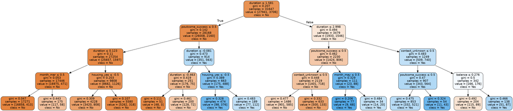

```python
train_char_label = ['No', 'Yes']
dot_data = StringIO()
export_graphviz(dtc, out_file=dot_data,
                filled=True, rounded=True,
                special_characters=True,feature_names=list(X_train), class_names=train_char_label)
graph = pydotplus.graph_from_dot_data(dot_data.getvalue())
graph.write_png('BankTermDipositDTree.png')
Image(graph.create_png())
```

```python
# Let's see all the important features used in DTree
print (pd.DataFrame(dtc.tree_.compute_feature_importances(normalize=False), columns=["Importance"], index = X_train.columns))
```

```
                     Importance
age                      0.0000
balance                  0.0002
day                      0.0000
duration                 0.0347
campaign                 0.0000
pdays                    0.0000
previous                 0.0000
job_blue-collar          0.0000
job_entrepreneur         0.0000
job_housemaid            0.0000
job_management           0.0000
job_retired              0.0000
job_self-employed        0.0000
job_services             0.0000
job_student              0.0000
job_technician           0.0000
job_unemployed           0.0000
job_unknown              0.0000
marital_married          0.0000
marital_single           0.0000
education_secondary      0.0000
education_tertiary       0.0000
education_unknown        0.0000
default_yes              0.0000
housing_yes              0.0031
loan_yes                 0.0000
contact_telephone        0.0000
contact_unknown          0.0011
month_aug                0.0000
month_dec                0.0000
month_feb                0.0000
month_jan                0.0000
month_jul                0.0000
month_jun                0.0000
month_mar                0.0010
month_may                0.0001
month_nov                0.0000
month_oct                0.0000
month_sep                0.0000
poutcome_other           0.0000
poutcome_success         0.0188
poutcome_unknown         0.0000
```

```python
# Let's compute all the performance related parameters
perf_matrix_d = computePerfMatrix(dtc, dtc_predict)
m_perf_matrix["DecisionTree"] = perf_matrix_d
```

```
Trainig dataset accuracy: 0.902960786172465

Testing dataset accuracy: 0.9003243880861103

Confusion Matrix:
```

[figure not shown]

```
None

Recall: 0.31143398610233736

Precision: 0.6529801324503312

F1 Score: 0.4217279726261763

Roc Auc Score: 0.6447830142514024
```

```python
# Visualize model's performance with yellowbrick library
visualizePerfMatrix(dtc)
```

[figure not shown]

#### `Observation 1:`

At this point, looking at Recall, precision, F1_score, ROC curve and AUC curve. When I compare the Logistic Regression and Decision Tree model, The Logistic regression model performs better

### `3.2 Let's implement various ensemble models`

#### `3.2.1 Random Forest classifier Model`

```python
# Let's apply RandomForestClassification model
rfc = RandomForestClassifier(n_estimators=50, criterion='gini', random_state=11)
rfc = rfc.fit(X_train, y_train)
# Predict the performance of the test samples
rfc_predict = rfc.predict(X_test)
```

```python
# Let's compute all the performance related parameters
perf_matrix_d = computePerfMatrix(rfc, rfc_predict)
#m_perf_matrix["RandomForest"] = perf_matrix_d
```

```
Trainig dataset accuracy: 0.9997788099977881

Testing dataset accuracy: 0.90555883220289

Confusion Matrix:
```

[figure not shown]

```
None

Recall: 0.3910296904611497

Precision: 0.6613247863247863

F1 Score: 0.49146486701071845

Roc Auc Score: 0.6822855655377279
```

```python
# Let's apply RandomForestClassification model with max_depth=4
rfc = RandomForestClassifier(n_estimators=50, criterion='gini', random_state=11, max_depth=4)

rfc = rfc.fit(X_train, y_train)
# Predict the performance of the test samples
rfc_predict = rfc.predict(X_test)
```

```python
# Let's compute all the performance related parameters
perf_matrix_d = computePerfMatrix(rfc, rfc_predict)
#m_perf_matrix["RandomForest"] = perf_matrix_d
```

```
Trainig dataset accuracy: 0.8927228489272285

Testing dataset accuracy: 0.8916986139781775

Confusion Matrix:
```

[figure not shown]

```
None

Recall: 0.09412507896399241

Precision: 0.8097826086956522

F1 Score: 0.16864742501414828

Roc Auc Score: 0.5456018934591267
```

```python
# Let's apply RandomForestClassification model with max_depth=4
rfc = RandomForestClassifier(n_estimators=50, criterion='gini', random_state=11, max_depth=4, bootstrap=True)

rfc = rfc.fit(X_train, y_train)
# Predict the performance of the test samples
rfc_predict = rfc.predict(X_test)
```

```python
# Let's compute all the performance related parameters
perf_matrix_d = computePerfMatrix(rfc, rfc_predict)
#m_perf_matrix["RandomForest"] = perf_matrix_d
```

```
Trainig dataset accuracy: 0.8927228489272285

Testing dataset accuracy: 0.8916986139781775

Confusion Matrix:
```

[figure not shown]

```
None

Recall: 0.09412507896399241

Precision: 0.8097826086956522

F1 Score: 0.16864742501414828

Roc Auc Score: 0.5456018934591267
```

#### Noted that adding the Max_depth and bootstrap reduces the model performance. so let's build final model without that.

```python
# Let's build final RandomForestClassification model
rfc = RandomForestClassifier(n_estimators=50, criterion='gini', random_state=11)
rfc = rfc.fit(X_train, y_train)
# Predict the performance of the test samples
rfc_predict = rfc.predict(X_test)
```

```python
# Let's compute all the performance related parameters
perf_matrix_d = computePerfMatrix(rfc, rfc_predict)
m_perf_matrix["RandomForest"] = perf_matrix_d
```

```
Trainig dataset accuracy: 0.9997788099977881

Testing dataset accuracy: 0.90555883220289

Confusion Matrix:
```

[figure not shown]

```
None

Recall: 0.3910296904611497

Precision: 0.6613247863247863

F1 Score: 0.49146486701071845

Roc Auc Score: 0.6822855655377279
```

```python
# Visualize model's performance with yellowbrick library
visualizePerfMatrix(rfc)
```

[figure not shown]

#### `Observation 2:`

At this point, looking at Recall, precision, F1_score, ROC curve and AUC curve. When I compare the LogisticRegression, DecisionTree and RandomForest models, The performance order of the models are as follow:

1. RandomForest
2. LogisticRegression
3. DecisionTree

#### `3.2.2 Adaboost Classifier Model`

```python
# Let's implement the adaboost emsemble classifier algorithm
abc = AdaBoostClassifier(n_estimators=50, learning_rate=0.1, random_state=11)
abc = abc.fit(X_train, y_train)
# Predict the performance of the tests samples
abc_predict = abc.predict(X_test)
```

```python
# Let's compute all the performance related parameters
perf_matrix_d = computePerfMatrix(abc, abc_predict)
m_perf_matrix["AdaBoost"] = perf_matrix_d
```

```
Trainig dataset accuracy: 0.888330647454735

Testing dataset accuracy: 0.8881598348569744

Confusion Matrix:
```

[figure not shown]

```
None

Recall: 0.054958938723941884

Precision: 0.8055555555555556

F1 Score: 0.10289769367238322

Roc Auc Score: 0.5266030817482493
```

```python
# Visualize model's performance with yellowbrick library
visualizePerfMatrix(abc)
```

[figure not shown]

#### `3.2.3 Bagging Classifier model`

```python
# Let's build bagging model
bgc = BaggingClassifier(n_estimators=50, max_samples=0.7, random_state=11)
bgc = bgc.fit(X_train, y_train)
# Predict the performance of the tests samples
bgc_predict = bgc.predict(X_test)
```

```python
# Let's compute all the performance related parameters
perf_matrix_d = computePerfMatrix(bgc, bgc_predict)
# m_perf_matrix["Bagging"] = perf_matrix_d
```

```
Trainig dataset accuracy: 0.9927323284987518

Testing dataset accuracy: 0.9046004128575641

Confusion Matrix:
```

[figure not shown]

```
None

Recall: 0.4542008843967151

Precision: 0.6257615317667538

F1 Score: 0.5263543191800878

Roc Auc Score: 0.7091553624888174
```

```python
# Let's build bagging model with bootstrap
bgc = BaggingClassifier(n_estimators=50, max_samples=0.7, random_state=11, bootstrap=True)
bgc = bgc.fit(X_train, y_train)
# Predict the performance of the tests samples
bgc_predict = bgc.predict(X_test)
```

```python
# Let's compute all the performance related parameters
perf_matrix_d = computePerfMatrix(bgc, bgc_predict)
# m_perf_matrix["Bagging"] = perf_matrix_d
```

```
Trainig dataset accuracy: 0.9927323284987518

Testing dataset accuracy: 0.9046004128575641

Confusion Matrix:
```

[figure not shown]

```
None

Recall: 0.4542008843967151

Precision: 0.6257615317667538

F1 Score: 0.5263543191800878

Roc Auc Score: 0.7091553624888174
```

```python
# Let's build bagging model oob_score
bgc = BaggingClassifier(n_estimators=50, max_samples=0.7, random_state=11, bootstrap=True, oob_score=True)
bgc = bgc.fit(X_train, y_train)
# Predict the performance of the tests samples
bgc_predict = bgc.predict(X_test)
```

```python
# Let's compute all the performance related parameters
perf_matrix_d = computePerfMatrix(bgc, bgc_predict)
# m_perf_matrix["Bagging"] = perf_matrix_d
```

```
Trainig dataset accuracy: 0.9927323284987518

Testing dataset accuracy: 0.9046004128575641

Confusion Matrix:
```

[figure not shown]

```
None

Recall: 0.4542008843967151

Precision: 0.6257615317667538

F1 Score: 0.5263543191800878

Roc Auc Score: 0.7091553624888174
```

#### Noted that adding bootstrap and oob_score has no impact on the model so let's build the final model with that.

```python
# Let's compute all the performance related parameters
perf_matrix_d = computePerfMatrix(bgc, bgc_predict)
m_perf_matrix["Bagging"] = perf_matrix_d
```

```
Trainig dataset accuracy: 0.9927323284987518

Testing dataset accuracy: 0.9046004128575641

Confusion Matrix:
```

[figure not shown]

```
None

Recall: 0.4542008843967151

Precision: 0.6257615317667538

F1 Score: 0.5263543191800878

Roc Auc Score: 0.7091553624888174
```

```python
# Visualize model's performance with yellowbrick library
visualizePerfMatrix(bgc)
```

[figure not shown]

#### `3.2.4 Gradient Boosting Classifier model`

```python
gbc = GradientBoostingClassifier(n_estimators=50, learning_rate = 0.1, random_state=11)
gbc = gbc.fit(X_train, y_train)
# Predict the performance of the tests samples
gbc_predict = gbc.predict(X_test)
```

```python
# Let's compute all the performance related parameters
perf_matrix_d = computePerfMatrix(gbc, gbc_predict)
# m_perf_matrix["GradientBoosting"] = perf_matrix_d
```

```
Trainig dataset accuracy: 0.9070686004992574

Testing dataset accuracy: 0.9039368917723385

Confusion Matrix:
```

[figure not shown]

```
None

Recall: 0.3638660770688566

Precision: 0.6605504587155964

F1 Score: 0.46924643584521386

Roc Auc Score: 0.6695801464553031
```

```python
gbc = GradientBoostingClassifier(n_estimators=50, learning_rate = 0.1, random_state=11, max_depth=4)
gbc = gbc.fit(X_train, y_train)
# Predict the performance of the tests samples
gbc_predict = gbc.predict(X_test)
```

```python
# Let's compute all the performance related parameters
perf_matrix_d = computePerfMatrix(gbc, gbc_predict)
# m_perf_matrix["GradientBoosting"] = perf_matrix_d
```

```
Trainig dataset accuracy: 0.9119347805479192

Testing dataset accuracy: 0.9052639339427897

Confusion Matrix:
```

[figure not shown]

```
None

Recall: 0.3897662665824384

Precision: 0.6591880341880342

F1 Score: 0.48987693529178233

Roc Auc Score: 0.6815703881113511
```

#### Noted that the max_depth improves overall perf for GradientBoost algo so let's build final model with that.

```python
# Let's compute all the performance related parameters
perf_matrix_d = computePerfMatrix(gbc, gbc_predict)
m_perf_matrix["GradientBoosting"] = perf_matrix_d
```

```
Trainig dataset accuracy: 0.9119347805479192

Testing dataset accuracy: 0.9052639339427897

Confusion Matrix:
```

[figure not shown]

```
None

Recall: 0.3897662665824384

Precision: 0.6591880341880342

F1 Score: 0.48987693529178233

Roc Auc Score: 0.6815703881113511
```

```python
# Visualize model's performance with yellowbrick library
visualizePerfMatrix(gbc)
```

[figure not shown]

## `Conclusion Summary`

```python
print(m_perf_matrix)
```

[output not shown]

```python
# Change dataframe precision to 4 points
pd.options.display.float_format = '{:,.4f}'.format

# Conver the dictionary to dataframe
summary_df = pd.DataFrame.from_dict(m_perf_matrix,orient='index').T
summary_df
```

|  | LogisticRegression | DecisionTree | RandomForest | AdaBoost | Bagging | GradientBoosting |
| --- | --- | --- | --- | --- | --- | --- |
| training_accuracy | 0.9026 | 0.9030 | 0.9998 | 0.8883 | 0.9927 | 0.9119 |
| test_accuracy | 0.9006 | 0.9003 | 0.9056 | 0.8882 | 0.9046 | 0.9053 |
| recall_score | 0.3342 | 0.3114 | 0.3910 | 0.0550 | 0.4542 | 0.3898 |
| precision_score | 0.6428 | 0.6530 | 0.6613 | 0.8056 | 0.6258 | 0.6592 |
| f1_score | 0.4397 | 0.4217 | 0.4915 | 0.1029 | 0.5264 | 0.4899 |
| roc_auc_score | 0.6548 | 0.6448 | 0.6823 | 0.5266 | 0.7092 | 0.6816 |

Noted following from about table:

1. The nest precision_score is observed in AdaBoost classifier but it perform poorly with other parameters
2. RandomForest and GradientBoosting algorithm shows better precision_score and other score.
3. If you consider the overall model, The Bagging is the best model

### `Confusion matrix:`

`True Positive (observed=1,predicted=1):`

Predicted that campaign will convert bank customers to subscribe term deposit

`False Positive (observed=0,predicted=1):`

Predicted that the campaign will convert bank customers to subscribe term deposit but the campaign will not convert customers to subscribe term deposit

`True Negative (observed=0,predicted=0):`

Predicted that campaign will not convert its bank customers to subscribe term deposit

`False Negative (observed=1,predicted=0):`

predicted that the customer will not convert bank customers to subscribe term deposit but the actual customer can be converted to subscribe term deposit.

### `Performance metrics`

`F1-score:` Weighted harmonic mean of the precision and recall. F1-score: 2*(precision x recall)/(precision + recall)

`Accuracy:` Fraction of all observations that were correctly classified by the model

`Macro avg:` Calculate metrics for each label, and find their unweighted mean. This does not take label imbalance into account

`Micro/weighted avg:` Calculate metrics globally by counting the total true positives, false negatives and false positives

`AUC Score:` Given a random observation from the dataset that belongs to a class, and a random observation that doesn't belong to a class, the AUC is the perecentage of time that our model will classify which is which correctly